# FIA - NLS Models: Biomass vs. Stand Age, G-Reconciled, Temporally-balanced

## predict and plot

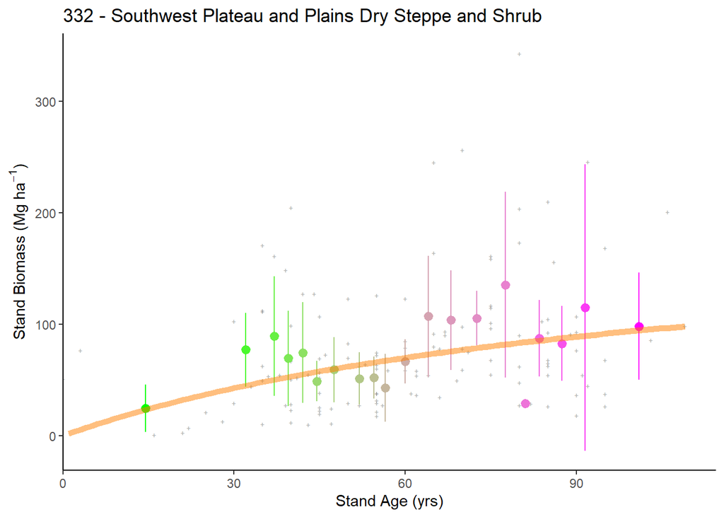

## plotting 2

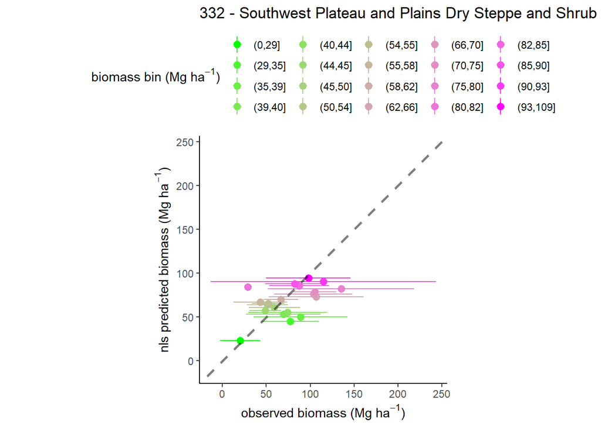

# 341 - Nevada-Utah Mountains Semi-Desert - Coniferous Forest - Alpine Meadow

## model selection 1

### summary

- simple model: does not fit
- phi model: does not fit
- phi-alpha model: does not fit

## model selection 2

### summary

- add p model: does not fit
- add s model: does not fit
- add s+p model: does not fit

## plot residuals

```
## [1] "cannot plot residuals"
```

## predict and plot

```
## [1] "cannot plot data with prediction"
```

## plotting 2

```
## [1] "cannot plot observed vs. predicted"
```

# 342 - Intermountain Semi-Desert

## model selection 1

### summary

- simple model: does not fit
- phi model: does not fit
- phi-alpha model: does not fit

## model selection 2

### summary

- add p model: does not fit
- add s model: does not fit
- add s+p model: does not fit

## plot residuals

```
## [1] "cannot plot residuals"
```

## predict and plot

```
## [1] "cannot plot data with prediction"
```

## plotting 2

```
## [1] "cannot plot observed vs. predicted"
```

# 411 - Everglades

## model selection 1

### summary

- simple model: does not fit
- phi model: does not fit
- phi-alpha model: does not fit

## model selection 2

### summary

- add p model: does not fit
- add s model: does not fit
- add s+p model: does not fit

## plot residuals

```
## [1] "cannot plot residuals"
```

## predict and plot

```
## [1] "cannot plot data with prediction"
```

## plotting 2

```
## [1] "cannot plot observed vs. predicted"
```

# M211 - Adirondack-New England Mixed forest - Coniferous Forest - Alpine Meadow

## model selection 1

```
## Analysis of Variance Table
##
## Model 1: B_plt_t2_MgHa ~ (1 + (MEASTIME_t2 - 1990) * ge/100) * A * STDAGE_t2/(k + STDAGE_t2)
## Model 2: B_plt_t2_MgHa ~ (1 + (MEASTIME_t2 - 1990) * ge/100) * (1 + phi * DeltaPDSI) * A * STDAGE_t2/(k + STDAGE_t2)
## Model 3: B_plt_t2_MgHa ~ (1 + (MEASTIME_t2 - 1990) * ge/100) * (1 + phi * DeltaPDSI) * (1 - alpha * B_L_prop) * A * STDAGE_t2/(k + STDAGE_t2)
##   Res.Df Res.Sum Sq Df  Sum Sq F value    Pr(>F)
## 1   5063     947.98
## 2   5062     940.98  1   6.998  37.648 9.116e-10 ***
## 3   5061     813.83  1 127.150 790.717 < 2.2e-16 ***
## ---
## Signif. codes:  0 '***' 0.001 '**' 0.01 '*' 0.05 '.' 0.1 ' ' 1
##   model      AIC
## 1     1 53682.82
## 2     2 53647.28
## 3     3 52913.85
```

```
##
## Formula: B_plt_t2_MgHa ~ (1 + (MEASTIME_t2 - 1990) * ge/100) * (1 + phi *
##     DeltaPDSI) * (1 - alpha * B_L_prop) * A * STDAGE_t2/(k +
##     STDAGE_t2)
##
## Parameters:
##        Estimate Std. Error t value Pr(>|t|)
## ge    2.471e-01  1.480e-01   1.669   0.0952 .
## phi   3.389e-02  6.446e-03   5.258 1.52e-07 ***
## alpha 8.182e-01  2.652e-02  30.855  < 2e-16 ***
## A     4.098e+02  2.351e+01  17.427  < 2e-16 ***
## k     1.663e+02  1.066e+01  15.610  < 2e-16 ***
## ---
## Signif. codes:  0 '***' 0.001 '**' 0.01 '*' 0.05 '.' 0.1 ' ' 1
##
## Residual standard error: 0.401 on 5061 degrees of freedom
##
## Number of iterations to convergence: 7
## Achieved convergence tolerance: 1.34e-06
##   (2 observations deleted due to missingness)
```

### summary

- simple model: fits
- phi model: fits
- phi-alpha model: fits

## model selection 2

```
## Error in numericDeriv(form[[3L]], names(ind), env, central = nDcentral) :
##   Missing value or an infinity produced when evaluating the model
## Analysis of Variance Table
##
## Model 1: B_plt_t2_MgHa ~ (1 + (MEASTIME_t2 - 1990) * ge/100) * (1 + phi * DeltaPDSI) * (1 - alpha * B_L_prop) * A * STDAGE_t2/(k + STDAGE_t2)
## Model 2: B_plt_t2_MgHa ~ (1 + (MEASTIME_t2 - 1990) * ge/100) * (1 + phi * DeltaPDSI) * (1 - alpha * B_L_prop) * (p * A + ((1 - p) * A * STDAGE_t2/(k + STDAGE_t2)))
##   Res.Df Res.Sum Sq Df Sum Sq F value    Pr(>F)
## 1   5061     813.83
## 2   5060     810.69  1 3.1321  19.549 1.001e-05 ***
## ---
## Signif. codes:  0 '***' 0.001 '**' 0.01 '*' 0.05 '.' 0.1 ' ' 1
##   model      AIC
## 1     3 52913.85
## 2    3a 52896.31
## 3    3b 52881.82
## 4    3c       NA
```

```
##
## Formula: B_plt_t2_MgHa ~ (1 + (MEASTIME_t2 - 1990) * ge/100) * (1 + phi *
##     DeltaPDSI) * (1 - alpha * B_L_prop) * (A * STDAGE_t2^s/(k^s +
##     STDAGE_t2^s))
##
## Parameters:
##        Estimate Std. Error t value Pr(>|t|)
## ge    2.022e-01  1.446e-01   1.398    0.162
## phi   3.235e-02  6.395e-03   5.059 4.37e-07 ***
## alpha 8.256e-01  2.664e-02  30.993  < 2e-16 ***
## A     2.484e+02  1.735e+01  14.316  < 2e-16 ***
## k     6.886e+01  6.958e+00   9.896  < 2e-16 ***
## s     1.318e+00  6.008e-02  21.929  < 2e-16 ***
## ---
## Signif. codes:  0 '***' 0.001 '**' 0.01 '*' 0.05 '.' 0.1 ' ' 1
##
## Residual standard error: 0.3997 on 5060 degrees of freedom
##
## Number of iterations to convergence: 8
## Achieved convergence tolerance: 1.56e-06
##   (2 observations deleted due to missingness)
```

### summary

- add p model: fits
- add s model: fits
- add s+p model: does not fit

## plot residuals

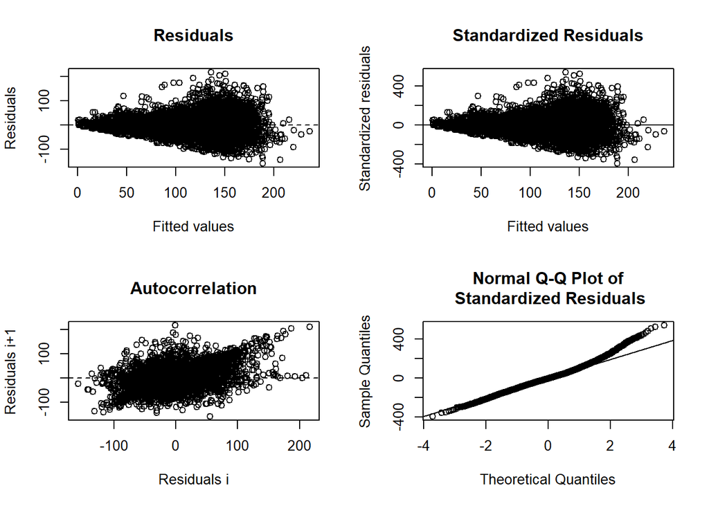

## predict and plot

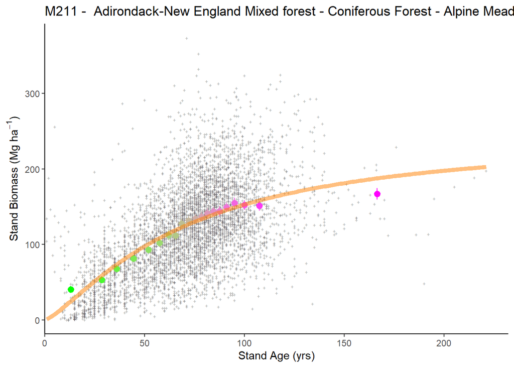

## plotting 2

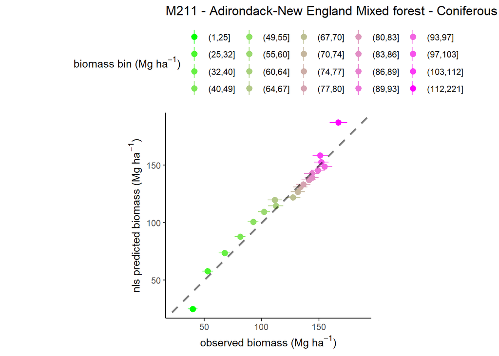

# M221 - Eastern Broadleaf Forest

## model selection 1

```
## Analysis of Variance Table
##
## Model 1: B_plt_t2_MgHa ~ (1 + (MEASTIME_t2 - 1990) * ge/100) * A * STDAGE_t2/(k + STDAGE_t2)
## Model 2: B_plt_t2_MgHa ~ (1 + (MEASTIME_t2 - 1990) * ge/100) * (1 + phi * DeltaPDSI) * A * STDAGE_t2/(k + STDAGE_t2)
## Model 3: B_plt_t2_MgHa ~ (1 + (MEASTIME_t2 - 1990) * ge/100) * (1 + phi * DeltaPDSI) * (1 - alpha * B_L_prop) * A * STDAGE_t2/(k + STDAGE_t2)
##   Res.Df Res.Sum Sq Df Sum Sq F value    Pr(>F)
## 1   5099     936.49
## 2   5098     927.14  1  9.345  51.387 8.669e-13 ***
## 3   5097     866.07  1 61.079 359.462 < 2.2e-16 ***
## ---
## Signif. codes:  0 '***' 0.001 '**' 0.01 '*' 0.05 '.' 0.1 ' ' 1
##   model      AIC
## 1     1 56350.11
## 2     2 56300.94
## 3     3 55955.25
```

```
##
## Formula: B_plt_t2_MgHa ~ (1 + (MEASTIME_t2 - 1990) * ge/100) * (1 + phi *
##     DeltaPDSI) * (1 - alpha * B_L_prop) * A * STDAGE_t2/(k +
##     STDAGE_t2)
##
## Parameters:
##         Estimate Std. Error t value Pr(>|t|)
## ge      0.835841   0.140027   5.969 2.55e-09 ***
## phi    -0.039252   0.005371  -7.308 3.14e-13 ***
## alpha   0.829307   0.041360  20.051  < 2e-16 ***
## A     255.033835   9.649011  26.431  < 2e-16 ***
## k      57.216106   2.955816  19.357  < 2e-16 ***
## ---
## Signif. codes:  0 '***' 0.001 '**' 0.01 '*' 0.05 '.' 0.1 ' ' 1
##
## Residual standard error: 0.4122 on 5097 degrees of freedom
##
## Number of iterations to convergence: 6
## Achieved convergence tolerance: 7.06e-06
##   (2 observations deleted due to missingness)
```

### summary

- simple model: fits
- phi model: fits
- phi-alpha model: fits

## model selection 2

```
## Analysis of Variance Table
##
## Model 1: B_plt_t2_MgHa ~ (1 + (MEASTIME_t2 - 1990) * ge/100) * (1 + phi * DeltaPDSI) * (1 - alpha * B_L_prop) * A * STDAGE_t2/(k + STDAGE_t2)
## Model 2: B_plt_t2_MgHa ~ (1 + (MEASTIME_t2 - 1990) * ge/100) * (1 + phi * DeltaPDSI) * (1 - alpha * B_L_prop) * (p * A + ((1 - p) * A * STDAGE_t2/(k + STDAGE_t2)))
## Model 3: B_plt_t2_MgHa ~ (1 + (MEASTIME_t2 - 1990) * ge/100) * (1 + phi * DeltaPDSI) * (1 - alpha * B_L_prop) * (A * STDAGE_t2^s/(k^s + STDAGE_t2^s))
## Model 4: B_plt_t2_MgHa ~ (1 + (MEASTIME_t2 - 1990) * ge/100) * (1 + phi * DeltaPDSI) * (1 - alpha * B_L_prop) * (p * A + ((1 - p) * A * STDAGE_t2^s/(k^s + STDAGE_t2^s)))
##   Res.Df Res.Sum Sq Df  Sum Sq  F value Pr(>F)
## 1   5097     866.07
## 2   5096     866.02  1  0.0505   0.2971 0.5858
## 3   5096     861.39  0  0.0000
## 4   5095     844.43  1 16.9623 102.3453 <2e-16 ***
## ---
## Signif. codes:  0 '***' 0.001 '**' 0.01 '*' 0.05 '.' 0.1 ' ' 1
##   model      AIC
## 1     3 55955.25
## 2    3a 55956.95
## 3    3b 55929.62
## 4    3c 55830.15
```

```
##
## Formula: B_plt_t2_MgHa ~ (1 + (MEASTIME_t2 - 1990) * ge/100) * (1 + phi *
##     DeltaPDSI) * (1 - alpha * B_L_prop) * (p * A + ((1 - p) *
##     A * STDAGE_t2^s/(k^s + STDAGE_t2^s)))
##
## Parameters:
##         Estimate Std. Error t value Pr(>|t|)
## ge      0.989374   0.147103   6.726 1.94e-11 ***
## phi    -0.038117   0.005291  -7.204 6.70e-13 ***
## alpha   0.831579   0.038656  21.512  < 2e-16 ***
## A     159.576527   5.451769  29.271  < 2e-16 ***
## k      38.625137   1.058712  36.483  < 2e-16 ***
## p       0.253254   0.019129  13.239  < 2e-16 ***
## s       2.909504   0.230108  12.644  < 2e-16 ***
## ---
## Signif. codes:  0 '***' 0.001 '**' 0.01 '*' 0.05 '.' 0.1 ' ' 1
##
## Residual standard error: 0.4071 on 5095 degrees of freedom
##
## Number of iterations to convergence: 9
## Achieved convergence tolerance: 7.979e-06
##   (2 observations deleted due to missingness)
```

### summary

- add p model: fits
- add s model: fits
- add s+p model: fits

## plot residuals

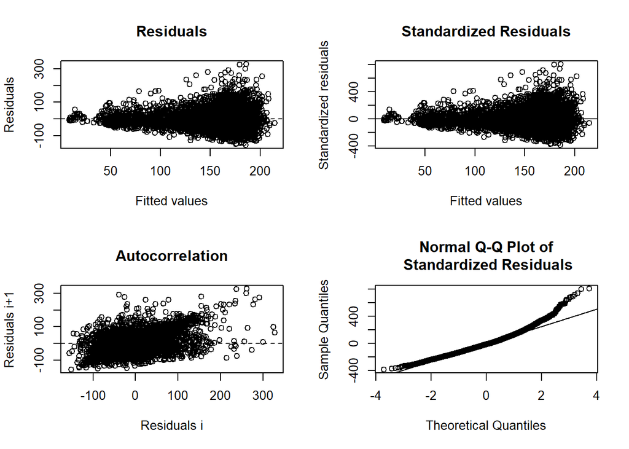

## predict and plot

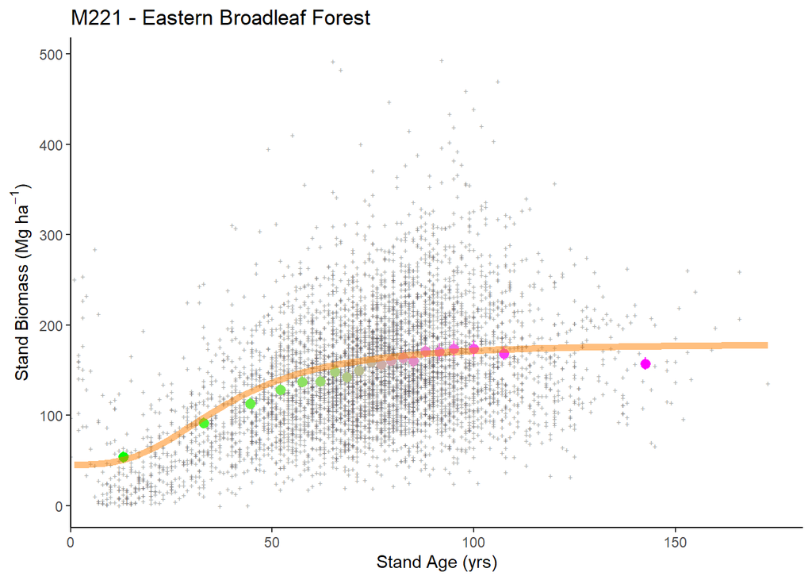

## plotting 2

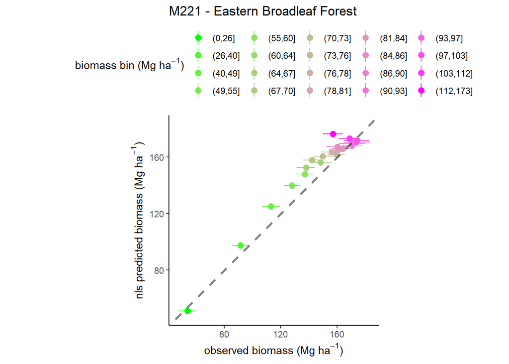

# M223 - Ozark Broadleaf Forest Meadow

## model selection 1

```
## Analysis of Variance Table
##
## Model 1: B_plt_t2_MgHa ~ (1 + (MEASTIME_t2 - 1990) * ge/100) * A * STDAGE_t2/(k + STDAGE_t2)
## Model 2: B_plt_t2_MgHa ~ (1 + (MEASTIME_t2 - 1990) * ge/100) * (1 + phi * DeltaPDSI) * A * STDAGE_t2/(k + STDAGE_t2)
## Model 3: B_plt_t2_MgHa ~ (1 + (MEASTIME_t2 - 1990) * ge/100) * (1 + phi * DeltaPDSI) * (1 - alpha * B_L_prop) * A * STDAGE_t2/(k + STDAGE_t2)
##   Res.Df Res.Sum Sq Df Sum Sq F value    Pr(>F)
## 1    592     89.416
## 2    591     86.841  1 2.5755  17.528 3.262e-05 ***
## 3    590     76.898  1 9.9428  76.286 < 2.2e-16 ***
## ---
## Signif. codes:  0 '***' 0.001 '**' 0.01 '*' 0.05 '.' 0.1 ' ' 1
##   model      AIC
## 1     1 6084.958
## 2     2 6069.568
## 3     3 5999.218
```

```
##
## Formula: B_plt_t2_MgHa ~ (1 + (MEASTIME_t2 - 1990) * ge/100) * (1 + phi *
##     DeltaPDSI) * (1 - alpha * B_L_prop) * A * STDAGE_t2/(k +
##     STDAGE_t2)
##
## Parameters:
##        Estimate Std. Error t value Pr(>|t|)
## ge     -0.76771    0.23812  -3.224 0.001334 **
## phi     0.09261    0.02388   3.879 0.000117 ***
## alpha   0.90123    0.09628   9.360  < 2e-16 ***
## A     313.38429   38.13149   8.219 1.31e-15 ***
## k      83.57812   14.68590   5.691 1.99e-08 ***
## ---
## Signif. codes:  0 '***' 0.001 '**' 0.01 '*' 0.05 '.' 0.1 ' ' 1
##
## Residual standard error: 0.361 on 590 degrees of freedom
##
## Number of iterations to convergence: 6
## Achieved convergence tolerance: 1.382e-06
##   (1 observation deleted due to missingness)
```

### summary

- simple model: fits
- phi model: fits
- phi-alpha model: fits

## model selection 2

```
## Error in nls(get(paste("f_", Mod.Sel1, "c", sep = "")), data = G_M223,  :
##   number of iterations exceeded maximum of 50
## Analysis of Variance Table
##
## Model 1: B_plt_t2_MgHa ~ (1 + (MEASTIME_t2 - 1990) * ge/100) * (1 + phi * DeltaPDSI) * (1 - alpha * B_L_prop) * A * STDAGE_t2/(k + STDAGE_t2)
## Model 2: B_plt_t2_MgHa ~ (1 + (MEASTIME_t2 - 1990) * ge/100) * (1 + phi * DeltaPDSI) * (1 - alpha * B_L_prop) * (p * A + ((1 - p) * A * STDAGE_t2/(k + STDAGE_t2)))
##   Res.Df Res.Sum Sq Df   Sum Sq F value Pr(>F)
## 1    590     76.898
## 2    589     76.836  1 0.062364  0.4781 0.4896
##   model      AIC
## 1     3 5999.218
## 2    3a 6000.736
## 3    3b 6001.178
## 4    3c       NA
```

```
##
## Formula: B_plt_t2_MgHa ~ (1 + (MEASTIME_t2 - 1990) * ge/100) * (1 + phi *
##     DeltaPDSI) * (1 - alpha * B_L_prop) * A * STDAGE_t2/(k +
##     STDAGE_t2)
##
## Parameters:
##        Estimate Std. Error t value Pr(>|t|)
## ge     -0.76771    0.23812  -3.224 0.001334 **
## phi     0.09261    0.02388   3.879 0.000117 ***
## alpha   0.90123    0.09628   9.360  < 2e-16 ***
## A     313.38429   38.13149   8.219 1.31e-15 ***
## k      83.57812   14.68590   5.691 1.99e-08 ***
## ---
## Signif. codes:  0 '***' 0.001 '**' 0.01 '*' 0.05 '.' 0.1 ' ' 1
##
## Residual standard error: 0.361 on 590 degrees of freedom
##
## Number of iterations to convergence: 6
## Achieved convergence tolerance: 1.382e-06
##   (1 observation deleted due to missingness)
```

### summary

- add p model: fits
- add s model: fits
- add s+p model: does not fit

## plot residuals

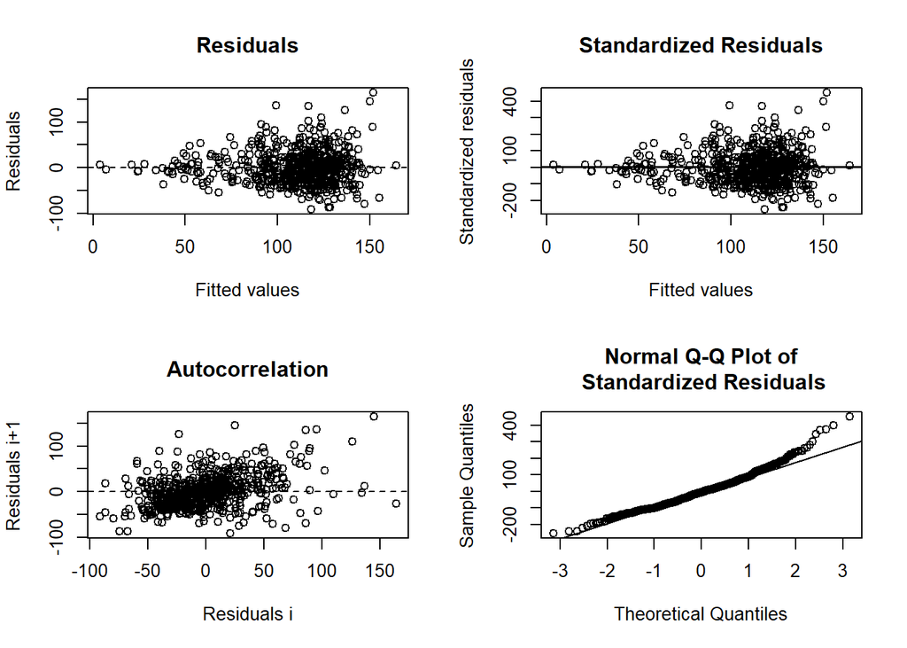

```
##
## ------
##  Shapiro-Wilk normality test
##
## data:  stdres
## W = 0.97251, p-value = 3.982e-09
##
##
## ------
```

```
##
##  Runs Test
##
## data:  as.factor(run)
## Standard Normal = -7.7151, p-value = 1.209e-14
## alternative hypothesis: two.sided
```

## predict and plot

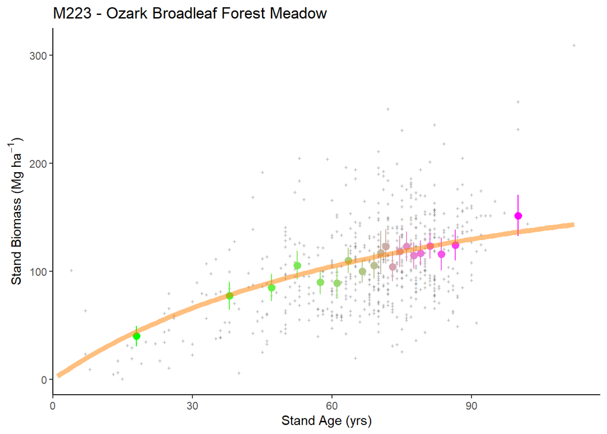

## plotting 2

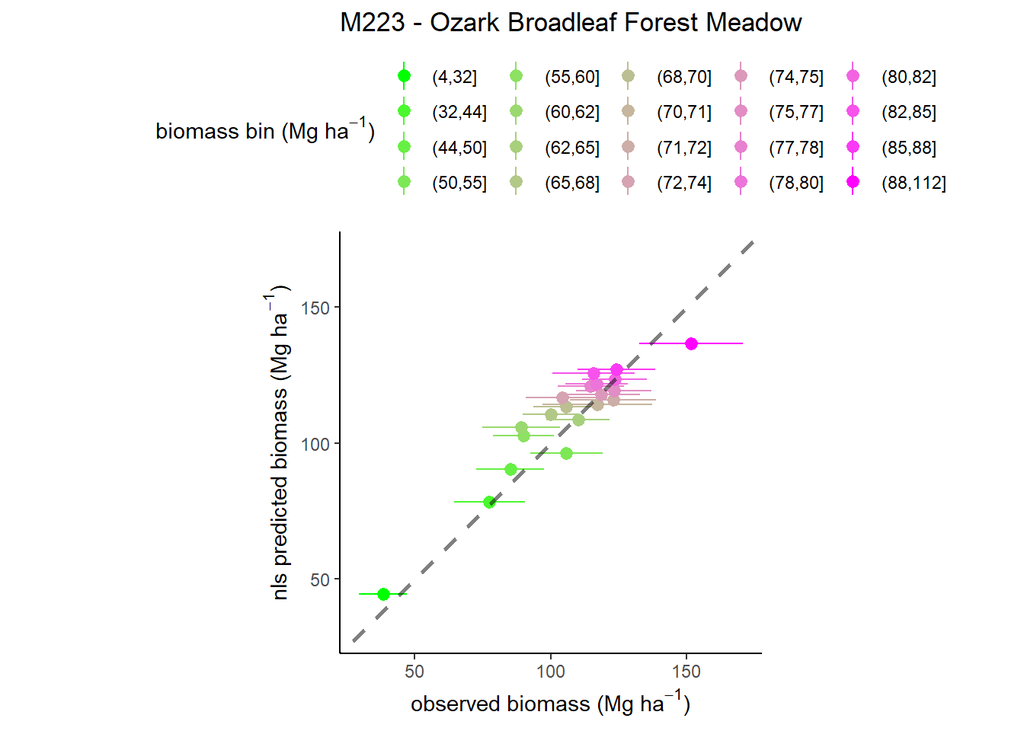

# M231 - Ouachita Mixed Forest

## model selection 1

```
## Analysis of Variance Table
##
## Model 1: B_plt_t2_MgHa ~ (1 + (MEASTIME_t2 - 1990) * ge/100) * A * STDAGE_t2/(k + STDAGE_t2)
## Model 2: B_plt_t2_MgHa ~ (1 + (MEASTIME_t2 - 1990) * ge/100) * (1 + phi * DeltaPDSI) * A * STDAGE_t2/(k + STDAGE_t2)
## Model 3: B_plt_t2_MgHa ~ (1 + (MEASTIME_t2 - 1990) * ge/100) * (1 + phi * DeltaPDSI) * (1 - alpha * B_L_prop) * A * STDAGE_t2/(k + STDAGE_t2)
##   Res.Df Res.Sum Sq Df  Sum Sq F value    Pr(>F)
## 1    664     165.96
## 2    663     165.91  1  0.0497  0.1987    0.6559
## 3    662     153.95  1 11.9582 51.4214 1.999e-12 ***
## ---
## Signif. codes:  0 '***' 0.001 '**' 0.01 '*' 0.05 '.' 0.1 ' ' 1
##   model      AIC
## 1     1 6903.950
## 2     2 6905.750
## 3     3 6857.854
```

```
##
## Formula: B_plt_t2_MgHa ~ (1 + (MEASTIME_t2 - 1990) * ge/100) * (1 + phi *
##     DeltaPDSI) * (1 - alpha * B_L_prop) * A * STDAGE_t2/(k +
##     STDAGE_t2)
##
## Parameters:
##         Estimate Std. Error t value Pr(>|t|)
## ge      0.724291   0.659021   1.099    0.272
## phi    -0.004849   0.026678  -0.182    0.856
## alpha   0.861683   0.112448   7.663 6.48e-14 ***
## A     285.155747  59.344428   4.805 1.92e-06 ***
## k     132.787434  29.364780   4.522 7.26e-06 ***
## ---
## Signif. codes:  0 '***' 0.001 '**' 0.01 '*' 0.05 '.' 0.1 ' ' 1
##
## Residual standard error: 0.4822 on 662 degrees of freedom
##
## Number of iterations to convergence: 6
## Achieved convergence tolerance: 2.796e-06
##   (1 observation deleted due to missingness)
```

### summary

- simple model: fits
- phi model: fits
- phi-alpha model: fits

## model selection 2

```
## Error in numericDeriv(form[[3L]], names(ind), env, central = nDcentral) :
##   Missing value or an infinity produced when evaluating the model
## Analysis of Variance Table
##
## Model 1: B_plt_t2_MgHa ~ (1 + (MEASTIME_t2 - 1990) * ge/100) * (1 + phi * DeltaPDSI) * (1 - alpha * B_L_prop) * A * STDAGE_t2/(k + STDAGE_t2)
## Model 2: B_plt_t2_MgHa ~ (1 + (MEASTIME_t2 - 1990) * ge/100) * (1 + phi * DeltaPDSI) * (1 - alpha * B_L_prop) * (p * A + ((1 - p) * A * STDAGE_t2/(k + STDAGE_t2)))
##   Res.Df Res.Sum Sq Df  Sum Sq F value Pr(>F)
## 1    662     153.95
## 2    661     153.75  1 0.19665  0.8454 0.3582
##   model      AIC
## 1     3 6857.854
## 2    3a 6859.001
## 3    3b 6859.325
## 4    3c       NA
```

```
##
## Formula: B_plt_t2_MgHa ~ (1 + (MEASTIME_t2 - 1990) * ge/100) * (1 + phi *
##     DeltaPDSI) * (1 - alpha * B_L_prop) * A * STDAGE_t2/(k +
##     STDAGE_t2)
##
## Parameters:
##         Estimate Std. Error t value Pr(>|t|)
## ge      0.724291   0.659021   1.099    0.272
## phi    -0.004849   0.026678  -0.182    0.856
## alpha   0.861683   0.112448   7.663 6.48e-14 ***
## A     285.155747  59.344428   4.805 1.92e-06 ***
## k     132.787434  29.364780   4.522 7.26e-06 ***
## ---
## Signif. codes:  0 '***' 0.001 '**' 0.01 '*' 0.05 '.' 0.1 ' ' 1
##
## Residual standard error: 0.4822 on 662 degrees of freedom
##
## Number of iterations to convergence: 6
## Achieved convergence tolerance: 2.796e-06
##   (1 observation deleted due to missingness)
```

### summary

- add p model: fits
- add s model: fits
- add s+p model: does not fit

## plot residuals

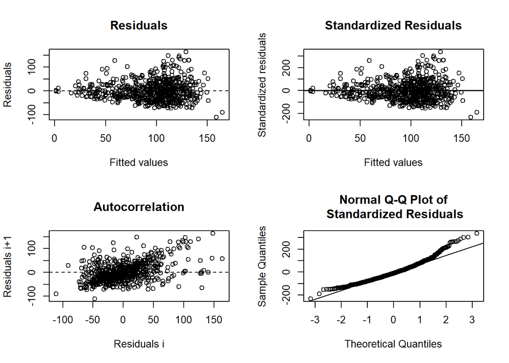

```
##
## ------
##  Shapiro-Wilk normality test
##
## data:  stdres
## W = 0.96074, p-value = 2.304e-12
##
##
## ------
```

```
##
##  Runs Test
##
## data:  as.factor(run)
## Standard Normal = -8.8249, p-value < 2.2e-16
## alternative hypothesis: two.sided
```

## predict and plot

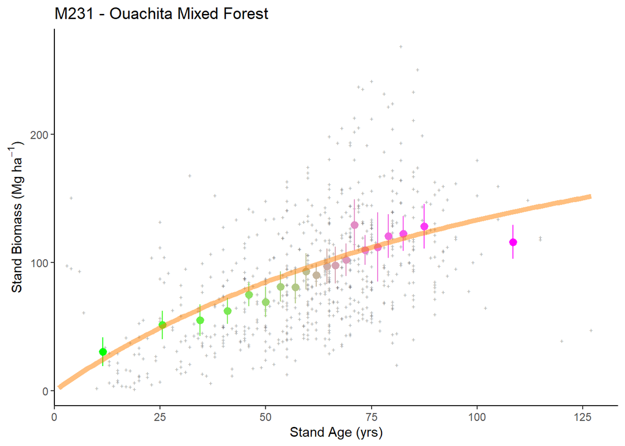

## plotting 2

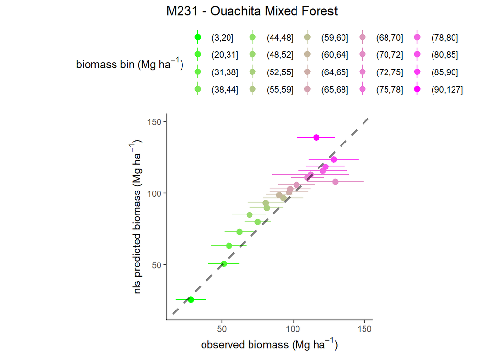

# M242 - Cascade Mixed Forest

## model selection 1

### summary

- simple model: does not fit
- phi model: does not fit
- phi-alpha model: does not fit

## model selection 2

### summary

- add p model: does not fit
- add s model: does not fit
- add s+p model: does not fit

## plot residuals

```
## [1] "cannot plot residuals"
```

## predict and plot

```
## [1] "cannot plot data with prediction"
```

## plotting 2

```
## [1] "cannot plot observed vs. predicted"
```

# M261 - Sierran Steppe - Mixed Forest - Coniferous Forest - Alpine Meadow

## model selection 1

[output not shown]

[output not shown]

### summary

- simple model: does not fit
- phi model: does not fit
- phi-alpha model: does not fit

## model selection 2

### summary

- add p model: does not fit
- add s model: does not fit
- add s+p model: does not fit

## plot residuals

```
## [1] "cannot plot residuals"
```

## predict and plot

```
## [1] "cannot plot data with prediction"
```

## plotting 2

```
## [1] "cannot plot data with prediction"
```

# M262 - California coastal range - coniferous forest - open woodland - shrub meadow

## Model selection 1

### summary

- simple model: does not fit
- phi model: does not fit
- phi-alpha model: does not fit

## model selection 2

### summary

- add p model: does not fit
- add s model: does not fit
- add s+p model: does not fit

## plot residuals

```
## [1] "cannot plot residuals"
```

## predict and plot

```
## [1] "cannot plot data with prediction"
```

## plotting 2

# M313 - Arizona-New Mexico Mountains Semi-Desert - Open Woodland - Coniferous Forest - Alpine Meadow

## model selection 1

[output not shown]

[output not shown]

### summary

- simple model: does not fit
- phi model: does not fit
- phi-alpha model: does not fit

## model selection 2

### summary

- add p model: does not fit
- add s model: does not fit
- add s+p model: does not fit

## plot residuals

```
## [1] "cannot plot residuals"
```

## predict and plot

```
## [1] "cannot plot data with prediction"
```

## plotting 2

# M331 - Southern Rocky Mountain Steppe - Open Woodland - Coniferous Forest - Alpine Meadow

## model selection 1

[output not shown]

[output not shown]

### summary

- simple model: does not fit
- phi model: does not fit
- phi-alpha model: does not fit

## model selection 2

### summary

- add p model: does not fit
- add s model: does not fit
- add s+p model: does not fit

## plot residuals

```
## [1] "cannot plot residuals"
```

## predict and plot

```
## [1] "cannot plot data with prediction"
```

## plotting 2

# M332 - Middle Rocky Mountain Steppe - Coniferous Forest - Alpine Meadow

## model selection 1

### summary

- simple model: does not fit
- phi model: does not fit
- phi-alpha model: does not fit

## model selection 2

### summary

- add p model: does not fit
- add s model: does not fit
- add s+p model: does not fit

## plot residuals

```
## [1] "cannot plot residuals"
```

## predict and plot

```
## [1] "cannot plot data with prediction"
```

## plotting 2

# M333 - Northern Rocky Mountain Steppe - Coniferous Forest - Alpine Meadow

## model selection 1

[output not shown]

[output not shown]

### summary

- simple model: does not fit
- phi model: does not fit
- phi-alpha model: does not fit

## model selection 2

### summary

- add p model: does not fit
- add s model: does not fit
- add s+p model: does not fit

## plot residuals

```
## [1] "cannot plot residuals"
```

## predict and plot

```
## [1] "cannot plot data with prediction"
```

## plotting 2

# M334 - Black Hills Coniferous Forest

## model selection 1

```
## Analysis of Variance Table
##
## Model 1: B_plt_t2_MgHa ~ (1 + (MEASTIME_t2 - 1990) * ge/100) * A * STDAGE_t2/(k + STDAGE_t2)
## Model 2: B_plt_t2_MgHa ~ (1 + (MEASTIME_t2 - 1990) * ge/100) * (1 + phi * DeltaPDSI) * A * STDAGE_t2/(k + STDAGE_t2)
## Model 3: B_plt_t2_MgHa ~ (1 + (MEASTIME_t2 - 1990) * ge/100) * (1 + phi * DeltaPDSI) * (1 - alpha * B_L_prop) * A * STDAGE_t2/(k + STDAGE_t2)
##   Res.Df Res.Sum Sq Df  Sum Sq F value    Pr(>F)
## 1    286     96.003
## 2    285     95.033  1  0.9697  2.9081   0.08923 .
## 3    284     83.668  1 11.3650 38.5770 1.865e-09 ***
## ---
## Signif. codes:  0 '***' 0.001 '**' 0.01 '*' 0.05 '.' 0.1 ' ' 1
##   model      AIC
## 1     1 2893.204
## 2     2 2892.270
## 3     3 2857.460
```

```
##
## Formula: B_plt_t2_MgHa ~ (1 + (MEASTIME_t2 - 1990) * ge/100) * (1 + phi *
##     DeltaPDSI) * (1 - alpha * B_L_prop) * A * STDAGE_t2/(k +
##     STDAGE_t2)
##
## Parameters:
##        Estimate Std. Error t value Pr(>|t|)
## ge     -0.86249    0.54117  -1.594    0.112
## phi     0.01478    0.03499   0.422    0.673
## alpha   0.84467    0.11999   7.039 1.45e-11 ***
## A     134.32297   28.27627   4.750 3.23e-06 ***
## k      55.36837   22.15481   2.499    0.013 *
## ---
## Signif. codes:  0 '***' 0.001 '**' 0.01 '*' 0.05 '.' 0.1 ' ' 1
##
## Residual standard error: 0.5428 on 284 degrees of freedom
##
## Number of iterations to convergence: 5
## Achieved convergence tolerance: 9.097e-06
##   (1 observation deleted due to missingness)
```

### summary

- simple model: fits
- phi model: fits
- phi-alpha model: fits

## model selection 2

```
## Analysis of Variance Table
##
## Model 1: B_plt_t2_MgHa ~ (1 + (MEASTIME_t2 - 1990) * ge/100) * (1 + phi * DeltaPDSI) * (1 - alpha * B_L_prop) * A * STDAGE_t2/(k + STDAGE_t2)
## Model 2: B_plt_t2_MgHa ~ (1 + (MEASTIME_t2 - 1990) * ge/100) * (1 + phi * DeltaPDSI) * (1 - alpha * B_L_prop) * (p * A + ((1 - p) * A * STDAGE_t2/(k + STDAGE_t2)))
## Model 3: B_plt_t2_MgHa ~ (1 + (MEASTIME_t2 - 1990) * ge/100) * (1 + phi * DeltaPDSI) * (1 - alpha * B_L_prop) * (A * STDAGE_t2^s/(k^s + STDAGE_t2^s))
## Model 4: B_plt_t2_MgHa ~ (1 + (MEASTIME_t2 - 1990) * ge/100) * (1 + phi * DeltaPDSI) * (1 - alpha * B_L_prop) * (p * A + ((1 - p) * A * STDAGE_t2^s/(k^s + STDAGE_t2^s)))
##   Res.Df Res.Sum Sq Df    Sum Sq F value Pr(>F)
## 1    284     83.668
## 2    283     83.667  1 0.0006208  0.0021 0.9635
## 3    283     83.667  0 0.0000000
## 4    282     83.665  1 0.0012039  0.0041 0.9493
##   model      AIC
## 1     3 2857.460
## 2    3a 2859.458
## 3    3b 2859.455
## 4    3c 2861.451
```

```
##
## Formula: B_plt_t2_MgHa ~ (1 + (MEASTIME_t2 - 1990) * ge/100) * (1 + phi *
##     DeltaPDSI) * (1 - alpha * B_L_prop) * A * STDAGE_t2/(k +
##     STDAGE_t2)
##
## Parameters:
##        Estimate Std. Error t value Pr(>|t|)
## ge     -0.86249    0.54117  -1.594    0.112
## phi     0.01478    0.03499   0.422    0.673
## alpha   0.84467    0.11999   7.039 1.45e-11 ***
## A     134.32297   28.27627   4.750 3.23e-06 ***
## k      55.36837   22.15481   2.499    0.013 *
## ---
## Signif. codes:  0 '***' 0.001 '**' 0.01 '*' 0.05 '.' 0.1 ' ' 1
##
## Residual standard error: 0.5428 on 284 degrees of freedom
##
## Number of iterations to convergence: 5
## Achieved convergence tolerance: 9.097e-06
##   (1 observation deleted due to missingness)
```

### summary

- add p model: fits
- add s model: fits
- add s+p model: fits

## plot residuals

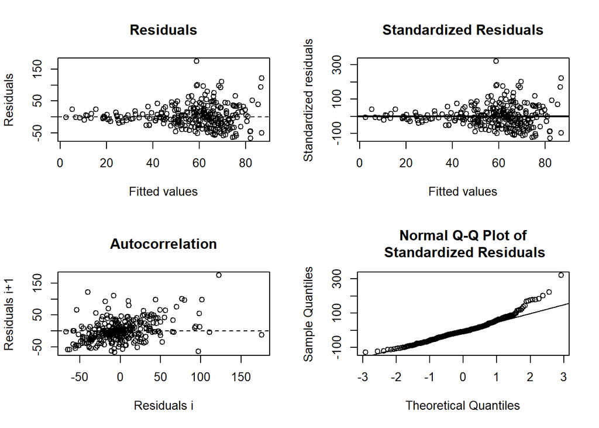

```
##
## ------
##  Shapiro-Wilk normality test
##
## data:  stdres
## W = 0.94662, p-value = 9.596e-09
##
##
## ------
```

```
##
##  Runs Test
##
## data:  as.factor(run)
## Standard Normal = -4.4013, p-value = 1.076e-05
## alternative hypothesis: two.sided
```

## predict and plot

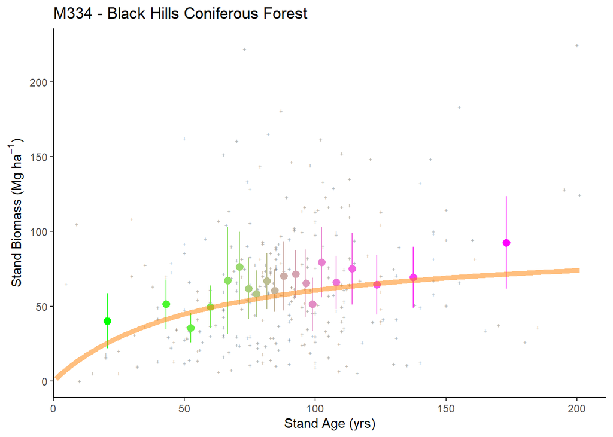

## plotting 2

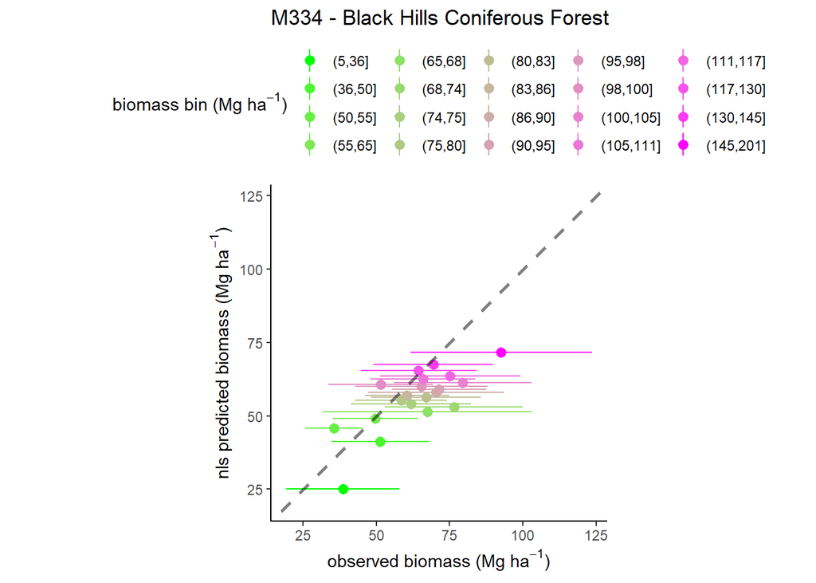

# M341 - Nevada-Utah Mountains Semi-Desert - Coniferous Forest - Alpine Meadow

## model selection 1

[output not shown]

[output not shown]

### summary

- simple model: does not fit
- phi model: does not fit
- phi-alpha model: does not fit

## model selection 2

### summary

- add p model: does not fit
- add s model: does not fit
- add s+p model: does not fit

## plot residuals

```
## [1] "cannot plot residuals"
```

## predict and plot

```
## [1] "cannot plot data with prediction"
```

## plotting 2

# Fitted parameters

## Best / selected models by ecoprovince

| Code | Ecoregion | Sel.Mod |
| --- | --- | --- |
| 211 | Northeastern Mixed Forest | 3b |
| 212 | Laurentian Mixed Forest | 3b |
| 221 | Eastern Broadleaf Forest | 3b |
| 222 | Midwest Broadleaf Forest | 3a |
| 223 | Central Interior Broadleaf Forest | 3c |
| 231 | Southeastern Mixed Forest | 3c |
| 232 | Outer Coastal Plain Mixed Forest | 3c |
| 234 | Lower Mississippi Riverine Forest | 3 |
| 242 | Pacific Lowland Mixed Forest | NA |
| 251 | Prairie Parkland (Temperate) | 3b |
| 255 | Prairie Parkland (Subtropical) | 3 |
| 261 | California Coastal Chaparral Forest and Shrub | NA |
| 262 | California Dry Steppe | NA |
| 263 | California Coastal Steppe - Mixed Forest and Redwood Forest | NA |
| 313 | Colorado Plateau Semi-Desert | NA |
| 315 | Southwest Plateau and Plains Dry Steppe and Shrub | NA |
| 321 | Chihuahuan Semi-Desert | NA |
| 322 | American Semidesert and Desert | NA |
| 331 | Great Plains/Palouse Dry Steppe | 1 |
| 332 | Great Plains Steppe | 3 |
| 341 | Intermountain Semi-Desert and Desert | NA |
| 342 | Intermountain Semi-Desert | NA |
| 411 | Everglades | NA |
| M211 | Adirondack-New England Mixed forest - Coniferous Forest - Alpine Meadow | 3b |
| M221 | Central Appalachian Broadleaf Forest - Coniferous Forest - Meadow | 3c |
| M223 | Ozark Broadleaf Forest Meadow | 3 |
| M231 | Ouachita Mixed Forest | 3 |
| M242 | Cascade Mixed Forest | NA |
| M261 | Sierran Steppe - Mixed Forest - Coniferous Forest - Alpine Meadow | NA |
| M262 | California Coastal Range Coniferous Forest - Open Woodland - Shrub - Meadow | NA |
| M313 | Arizona-New Mexico Mountains Semi-Desert - Open Woodland - Coniferous Forest - Alpine Meadow | NA |
| M331 | Southern Rocky Mountain Steppe - Open Woodland - Coniferous Forest - Alpine Meadow | NA |
| M332 | Middle Rocky Mountain Steppe - Coniferous Forest - Alpine Meadow | NA |
| M333 | Northern Rocky Mountain Steppe - Coniferous Forest - Alpine Meadow | NA |
| M334 | Black Hills Coniferous Forest | 3 |
| M341 | Nevada-Utah Mountains Semi-Desert - Coniferous Forest - Alpine Meadow | NA |

## table by ecoprovince

| Code | Ecoregion | region | n.obs | n.plots | ge | ge.2.5 | ge.97.5 | phi | phi.2.5 | phi.97.5 | alpha | alpha.2.5 | alpha.97.5 | A | A.2.5 | A.97.5 | k | k.2.5 | k.97.5 |
| --- | --- | --- | --- | --- | --- | --- | --- | --- | --- | --- | --- | --- | --- | --- | --- | --- | --- | --- | --- |
| 211 | Northeastern Mixed Forest | east | 4776 | 2388 | 0.1172919 | -0.2470393 | 0.4816230 | 0.0145539 | 0.0005265 | 0.0285814 | 0.8616573 | 0.7940221 | 0.9292924 | 308.55512 | 234.96903 | 382.1412 | 91.75522 | 58.97720 | 124.53324 |
| 212 | Laurentian Mixed Forest | east | 11688 | 5844 | 0.5634212 | 0.3075233 | 0.8193192 | 0.0013831 | -0.0072257 | 0.0099919 | 0.7820622 | 0.7205842 | 0.8435401 | 150.62428 | 133.62393 | 167.6246 | 52.54059 | 42.93732 | 62.14386 |
| 221 | Eastern Broadleaf Forest | east | 5350 | 2675 | 0.3267748 | 0.0483368 | 0.6052128 | -0.0070449 | -0.0173955 | 0.0033057 | 0.8501072 | 0.7888795 | 0.9113349 | 293.39163 | 246.36265 | 340.4206 | 65.21874 | 50.21110 | 80.22638 |
| 222 | Midwest Broadleaf Forest | east | 3248 | 1624 | -0.0712281 | -0.5257277 | 0.3832715 | 0.0363014 | 0.0126084 | 0.0599945 | 0.8715979 | 0.7699138 | 0.9732819 | 389.93264 | 291.43324 | 488.4320 | 149.40778 | 94.53260 | 204.28296 |
| 223 | Central Interior Broadleaf Forest | east | 6046 | 3023 | 0.3333948 | 0.0715697 | 0.5952200 | -0.0103828 | -0.0225283 | 0.0017626 | 0.7787262 | 0.7170197 | 0.8404328 | 143.83206 | 132.77114 | 154.8930 | 40.72912 | 38.06871 | 43.38952 |
| 231 | Southeastern Mixed Forest | east | 7532 | 3766 | 1.4747856 | 1.1853314 | 1.7642398 | -0.0091099 | -0.0191565 | 0.0009367 | 0.7570443 | 0.7067347 | 0.8073539 | 158.97972 | 143.58018 | 174.3793 | 32.98388 | 29.84517 | 36.12260 |
| 232 | Outer Coastal Plain Mixed Forest | east | 7568 | 3784 | 0.9769872 | 0.6626984 | 1.2912761 | 0.0299630 | 0.0170682 | 0.0428578 | 0.7396512 | 0.6779552 | 0.8013473 | 186.92313 | 155.38584 | 218.4604 | 39.98281 | 31.74126 | 48.22436 |
| 234 | Lower Mississippi Riverine Forest | east | 784 | 392 | 0.3743188 | -0.6691785 | 1.4178160 | 0.0082633 | -0.0366725 | 0.0531990 | 0.8132489 | 0.6810861 | 0.9454117 | 509.39871 | 287.94158 | 730.8558 | 158.99106 | 80.73530 | 237.24683 |
| 242 | Pacific Lowland Mixed Forest | pacific | 0 | 0 | NA | NA | NA | NA | NA | NA | NA | NA | NA | NA | NA | NA | NA | NA | NA |
| 251 | Prairie Parkland (Temperate) | east | 1248 | 624 | 0.6024100 | -0.2115888 | 1.4164087 | -0.0150036 | -0.0429414 | 0.0129343 | 0.7128461 | 0.5547401 | 0.8709522 | 143.33395 | 111.18263 | 175.4853 | 39.23881 | 30.56067 | 47.91694 |
| 255 | Prairie Parkland (Subtropical) | pacific | 410 | 205 | 0.1158176 | -0.8532456 | 1.0848808 | -0.0277224 | -0.0991957 | 0.0437509 | 0.8005794 | 0.5448413 | 1.0563176 | 169.21022 | 113.15624 | 225.2642 | 47.54576 | 26.69222 | 68.39929 |
| 261 | California Coastal Chaparral Forest and Shrub | pacific | 0 | 0 | NA | NA | NA | NA | NA | NA | NA | NA | NA | NA | NA | NA | NA | NA | NA |
| 262 | California Dry Steppe | pacific | 0 | 0 | NA | NA | NA | NA | NA | NA | NA | NA | NA | NA | NA | NA | NA | NA | NA |
| 263 | California Coastal Steppe - Mixed Forest and Redwood Forest | pacific | 0 | 0 | NA | NA | NA | NA | NA | NA | NA | NA | NA | NA | NA | NA | NA | NA | NA |
| 313 | Colorado Plateau Semi-Desert | interior west | 0 | 0 | NA | NA | NA | NA | NA | NA | NA | NA | NA | NA | NA | NA | NA | NA | NA |
| 315 | Southwest Plateau and Plains Dry Steppe and Shrub | interior west | 0 | 0 | NA | NA | NA | NA | NA | NA | NA | NA | NA | NA | NA | NA | NA | NA | NA |
| 321 | Chihuahuan Semi-Desert | interior west | 0 | 0 | NA | NA | NA | NA | NA | NA | NA | NA | NA | NA | NA | NA | NA | NA | NA |
| 322 | American Semidesert and Desert | interior west | 0 | 0 | NA | NA | NA | NA | NA | NA | NA | NA | NA | NA | NA | NA | NA | NA | NA |
| 331 | Great Plains/Palouse Dry Steppe | interior west | 104 | 52 | 1.0501855 | -4.0707187 | 6.1710896 | NA | NA | NA | NA | NA | NA | 63.46241 | -20.43442 | 147.3592 | 32.80273 | -54.95198 | 120.55743 |
| 332 | Great Plains Steppe | interior west | 132 | 66 | 12.8615094 | -49.3554555 | 75.0784743 | -0.0054884 | -0.1362431 | 0.1252662 | 1.0603145 | 0.5982389 | 1.5223900 | 57.14187 | -148.56537 | 262.8491 | 105.69839 | -70.78556 | 282.18234 |
| 341 | Intermountain Semi-Desert and Desert | interior west | 0 | 0 | NA | NA | NA | NA | NA | NA | NA | NA | NA | NA | NA | NA | NA | NA | NA |
| 342 | Intermountain Semi-Desert | interior west | 2 | 1 | NA | NA | NA | NA | NA | NA | NA | NA | NA | NA | NA | NA | NA | NA | NA |
| 411 | Everglades | east | 64 | 32 | NA | NA | NA | NA | NA | NA | NA | NA | NA | NA | NA | NA | NA | NA | NA |
| M211 | Adirondack-New England Mixed forest - Coniferous Forest - Alpine Meadow | east | 5068 | 2534 | 0.2021672 | -0.0813397 | 0.4856741 | 0.0323520 | 0.0198144 | 0.0448895 | 0.8255890 | 0.7733665 | 0.8778115 | 248.35003 | 214.34134 | 282.3587 | 68.85690 | 55.21641 | 82.49739 |
| M221 | Central Appalachian Broadleaf Forest - Coniferous Forest - Meadow | east | 5104 | 2552 | 0.9893737 | 0.7009883 | 1.2777590 | -0.0381167 | -0.0484893 | -0.0277441 | 0.8315785 | 0.7557958 | 0.9073613 | 159.57653 | 148.88872 | 170.2643 | 38.62514 | 36.54961 | 40.70067 |
| M223 | Ozark Broadleaf Forest Meadow | east | 596 | 298 | -0.7677104 | -1.2353839 | -0.3000370 | 0.0926132 | 0.0457202 | 0.1395061 | 0.9012320 | 0.7121320 | 1.0903321 | 313.38429 | 238.49433 | 388.2743 | 83.57812 | 54.73511 | 112.42113 |
| M231 | Ouachita Mixed Forest | east | 668 | 334 | 0.7242908 | -0.5697322 | 2.0183138 | -0.0048492 | -0.0572327 | 0.0475342 | 0.8616830 | 0.6408849 | 1.0824811 | 285.15575 | 168.62976 | 401.6817 | 132.78743 | 75.12811 | 190.44676 |
| M242 | Cascade Mixed Forest | pacific | 6 | 3 | NA | NA | NA | NA | NA | NA | NA | NA | NA | NA | NA | NA | NA | NA | NA |
| M261 | Sierran Steppe - Mixed Forest - Coniferous Forest - Alpine Meadow | pacific | 0 | 0 | NA | NA | NA | NA | NA | NA | NA | NA | NA | NA | NA | NA | NA | NA | NA |
| M262 | California Coastal Range Coniferous Forest - Open Woodland - Shrub - Meadow | interior west | 0 | 0 | NA | NA | NA | NA | NA | NA | NA | NA | NA | NA | NA | NA | NA | NA | NA |
| M313 | Arizona-New Mexico Mountains Semi-Desert - Open Woodland - Coniferous Forest - Alpine Meadow | interior west | 0 | 0 | NA | NA | NA | NA | NA | NA | NA | NA | NA | NA | NA | NA | NA | NA | NA |
| M331 | Southern Rocky Mountain Steppe - Open Woodland - Coniferous Forest - Alpine Meadow | interior west | 0 | 0 | NA | NA | NA | NA | NA | NA | NA | NA | NA | NA | NA | NA | NA | NA | NA |
| M332 | Middle Rocky Mountain Steppe - Coniferous Forest - Alpine Meadow | interior west | 2 | 1 | NA | NA | NA | NA | NA | NA | NA | NA | NA | NA | NA | NA | NA | NA | NA |
| M333 | Northern Rocky Mountain Steppe - Coniferous Forest - Alpine Meadow | interior west | 0 | 0 | NA | NA | NA | NA | NA | NA | NA | NA | NA | NA | NA | NA | NA | NA | NA |
| M334 | Black Hills Coniferous Forest | interior west | 290 | 145 | -0.8624932 | -1.9277068 | 0.2027204 | 0.0147781 | -0.0540949 | 0.0836511 | 0.8446661 | 0.6084805 | 1.0808518 | 134.32297 | 78.66532 | 189.9806 | 55.36837 | 11.75991 | 98.97683 |
| M341 | Nevada-Utah Mountains Semi-Desert - Coniferous Forest - Alpine Meadow | interior west | 0 | 0 | NA | NA | NA | NA | NA | NA | NA | NA | NA | NA | NA | NA | NA | NA | NA |

## plot ge

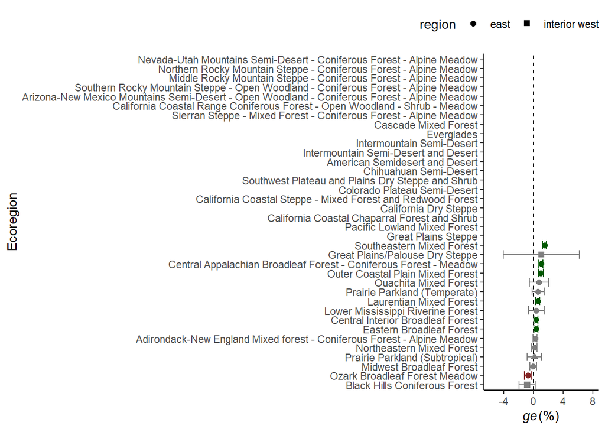

### map

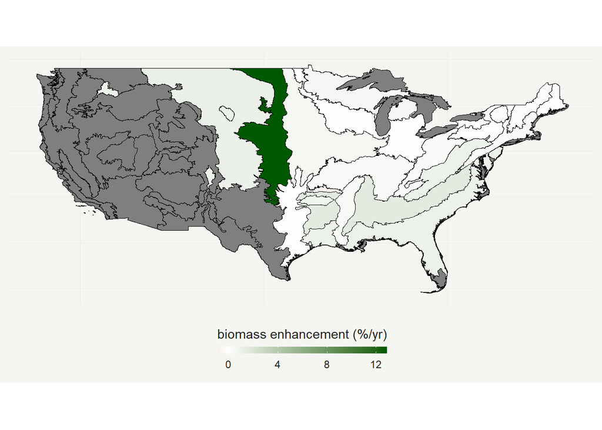

### map #2

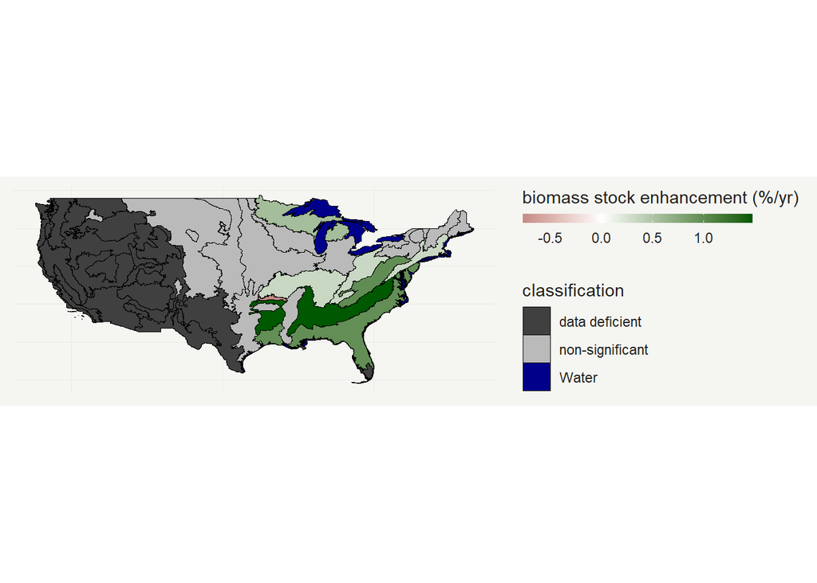

## plot phi (effect of DeltaPDSI)

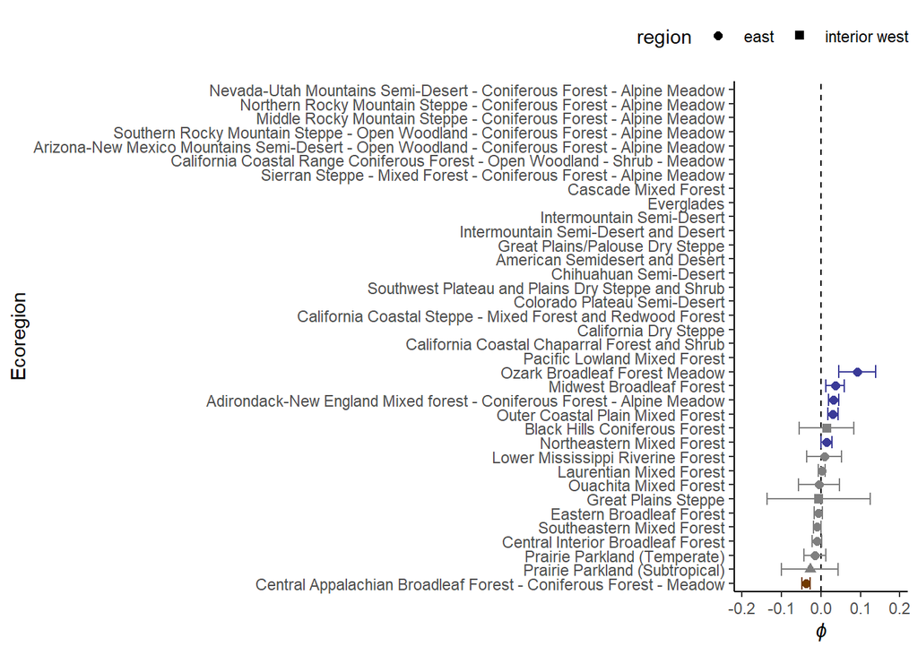

## plot alpha (biomass compensation effect)

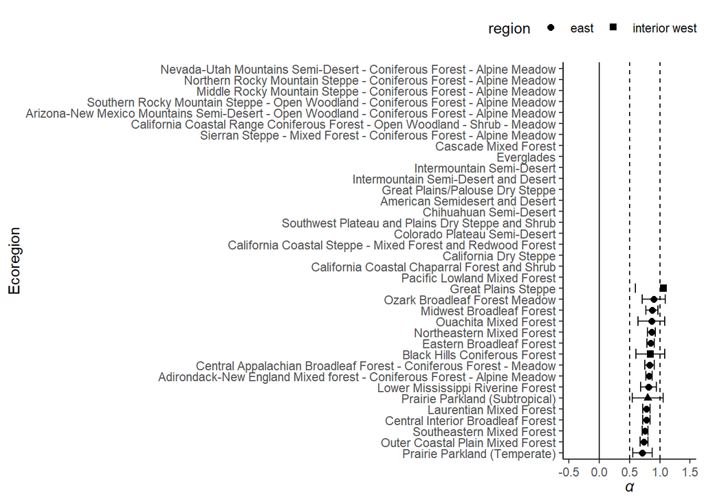

## plot A (asymptote of B)

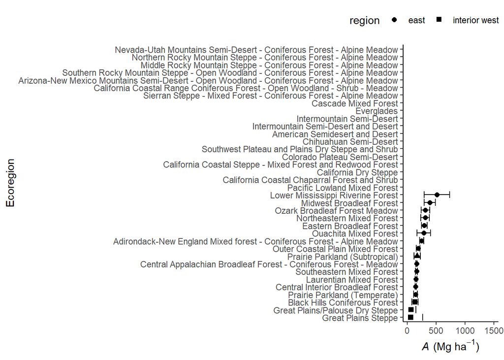

## plot k (stand age at half biomass asymptote)

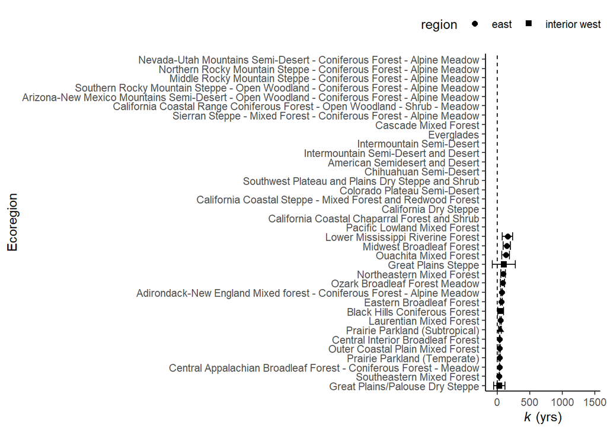

# Caclulations - weighted averages

## ge (stand biomass enhancement factor in % 2000-2021)

```
##          region weighted.ge
## 1     entire US   0.6250234
## 2       pacific   0.1141471
## 3          east   0.6080661
## 4 interior west   2.9373877
```

## phi (effect of DeltaPDSI)

```
##          region weighted.phi
## 1     entire US  0.004326884
## 2       pacific -0.027322572
## 3          east  0.004526051
## 4 interior west  0.006719193
```

## alpha (biomass compensation effect)

```
##          region weighted.alpha
## 1     entire US      0.7979522
## 2       pacific      0.7890326
## 3          east      0.7986504
## 4 interior west      0.7262541
```

## A (asymptote of forest biomass in Mg/ha)

```
##          region weighted.A
## 1     entire US   209.3247
## 2       pacific   166.7697
## 3          east   210.5893
## 4 interior west     0.0000
```

## K (stand age at half maturation in years)

```
##          region weighted.k
## 1     entire US   59.23844
## 2       pacific   46.86000
## 3          east   59.29076
## 4 interior west   63.05754
```

# Calculations - weighted averages subsetted to 15 ecoprovinces

- 211, 212, 221, 223, 231, 232, 234, 251, M211, M221, M223, M231, M242, M261, M332,

## ge

```
##          region weighted.ge
## 1     entire US   0.6477642
## 2       pacific   0.0000000
## 3          east   0.6478560
## 4 interior west   0.0000000
```

## phi

```
##          region weighted.phi
## 1     entire US  0.002701808
## 2       pacific  0.000000000
## 3          east  0.002702191
## 4 interior west  0.000000000
```

## alpha

```
##          region weighted.alpha
## 1     entire US      0.7952447
## 2       pacific      0.0000000
## 3          east      0.7953574
## 4 interior west      0.0000000
```